# Final Project

### Pruned Tree Model

I began with constructing a simple pruned tree model, with the hopes of answering if I would want a more complex model such as a random forest model. In order to construct my pruned tree model, I made a workflow, in which I defined that I was going to tune cost_complexity, created a grid for my cost complexity values, and tuned the model using the folds created above.

```r
# model
pruned_tree_model <- decision_tree() %>%
  set_engine("rpart") %>%
  set_mode("regression")
# workflow
pruned_tree_tune_wkflow <- workflow() %>%
  add_model(pruned_tree_model %>%
              set_args(cost_complexity = tune())) %>%
  add_recipe(movies_recipe)
# create grid for values of cost complexity
pruned_cost_grid <- grid_regular(cost_complexity(range(-3,-1)),
                                 levels=10)
# tune
pruned_tune_res <- tune_grid(
  pruned_tree_tune_wkflow,
  resamples = movies_fold,
  grid = pruned_cost_grid)
```

I then plotted the resulting rsq and rmse values for different values of cost complexity

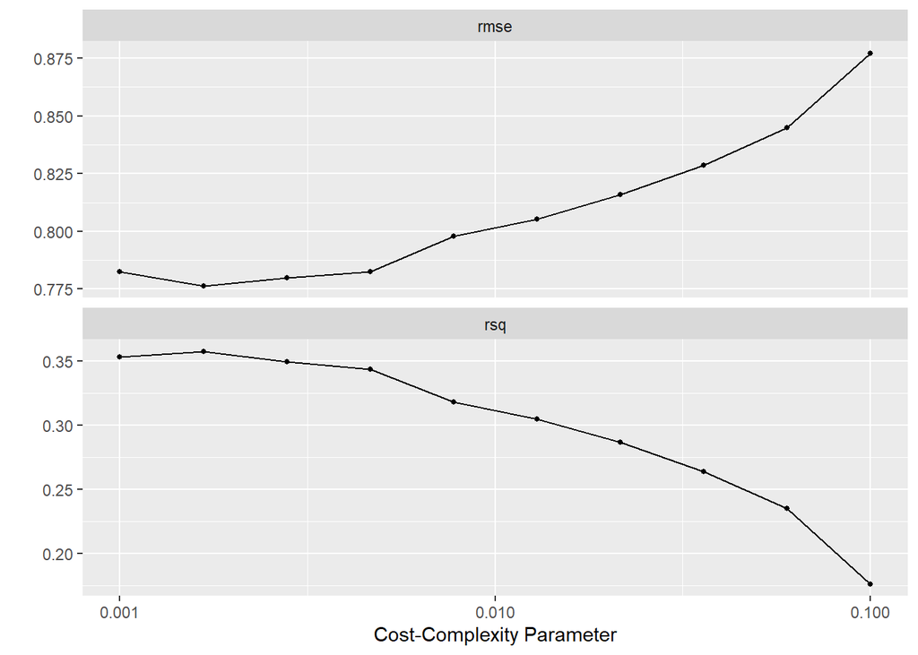

```r
autoplot(pruned_tune_res)
```

```r
best_complexity <- select_best(pruned_tune_res,
                               metric = "rmse")
best_complexity
```

```
## # A tibble: 1 x 2
##   cost_complexity .config
##             <dbl> <chr>
## 1         0.00167 Preprocessor1_Model02
```

```r
pruned_tree_tune_final <- finalize_workflow(
  pruned_tree_tune_wkflow, best_complexity)
pruned_tree_tune_final_fit <- fit(
  pruned_tree_tune_final,
  data = movies_train)
```

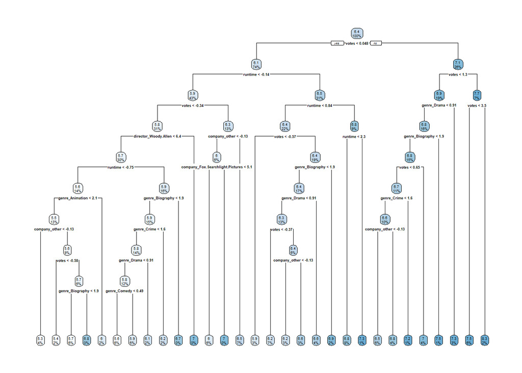

```r
# visualize the model
pruned_tree_tune_final_fit %>%
  extract_fit_engine() %>%
  rpart.plot()
```

As observed from the rmse and cost-complexity plot, our model performed best with a more complex tree.

```r
# check performance
augment(pruned_tree_tune_final_fit, new_data = movies_train) %>%
  rmse(truth = score, estimate = .pred)
```

```
## # A tibble: 1 x 3
##   .metric .estimator .estimate
##   <chr>   <chr>          <dbl>
## 1 rmse    standard       0.739
```

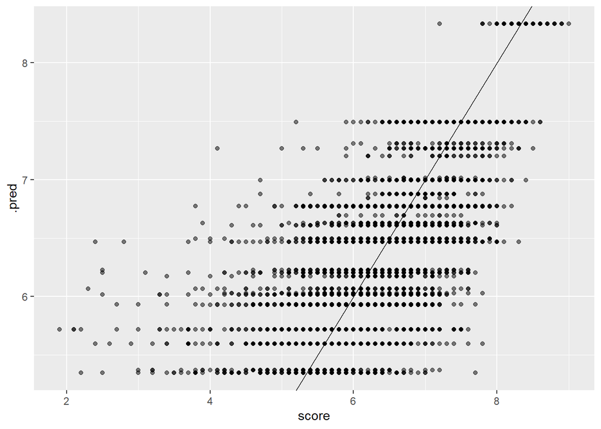

```r
augment(pruned_tree_tune_final_fit,
        new_data = movies_train) %>%
  ggplot(aes(score, .pred)) +
  geom_abline() +
  geom_point(alpha = 0.5)
```

Overall, our model did not perform that great. We got a relatively high rmse value, and our model appears to have high bias and high variance since the model is predicting the same value for a large range of actual values.

### Random Forest Model

From our pruned tree anlaysis we determined that a more complex model would serve our dataset better. Thus, we will constucted a random forest model. In order to do this, I created a specification with the engine “ranger”, put importance = “impurity” to use the Gini index and created a workflow specifying I woul be tuning mtry, trees, and min_n. I created a grid with possible values, and chose I range of 1 to 7 for mtry, because we want at least one predictor and have a maximum of 7 predictors in the recipe. I created a range of 10 to 50 for trees, and a range of 1 to 100 for min_n, which specifies the smalles amount of observations to have at a node for it to stop. I then tuned my model, which took around 45 minutes, and then saved the results so I would not have to run it again.

After tuning the model, I output the results in order to see the effects of different minimal node size, predictors, and trees on the rmse value of the folds.

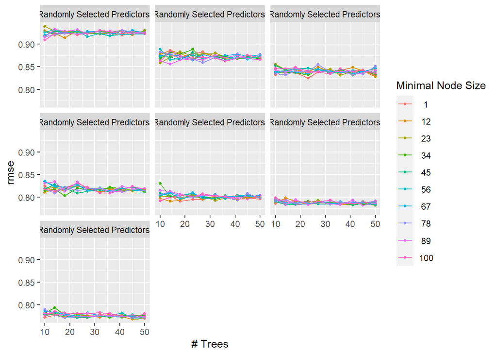

```r
load(file = "C:\\Users\\kathe\\OneDrive\\Desktop\\PSTAT 131\\131-Final-Project\\Data\\random_forest_runs.rda")
autoplot(rf_param_res, metric = "rmse")
```

From the plot we observe that the model obtains a better rmse score when the number of selected parameters increases and the minimal number of nodes is 12. In addition, the model does best with trees past 35.

Next, we will use select_best to select the best min_n, trees, and mtry combination from the plot above and fit out model to it with the training set.

```r
best_predictors <- select_best(rf_param_res,
                               metric = "rmse")
best_predictors
```

```
## # A tibble: 1 x 4
##    mtry trees min_n .config
##   <int> <int> <int> <chr>
## 1     7    45    12 Preprocessor1_Model133
```

```r
rf_final <- finalize_workflow(
  rf_wkflow, best_predictors)
rf_final_fit <- fit(
  rf_final,
  data = movies_train)
```

As we observed from the plot, the model performed best with a minimal node size of 12, 45 trees, and all 7 of the predictors. Now let’s see how this model performed on the training by viewing the rmse value.

```r
augment(rf_final_fit,
        new_data = movies_train) %>%
  rmse(truth = score, estimate = .pred)
```

```
## # A tibble: 1 x 3
##   .metric .estimator .estimate
##   <chr>   <chr>          <dbl>
## 1 rmse    standard       0.753
```

Interestingly we got a worse rmse value from our random forest model that we did from the pruned tree. Lets view a plot of our predicted and expected values.

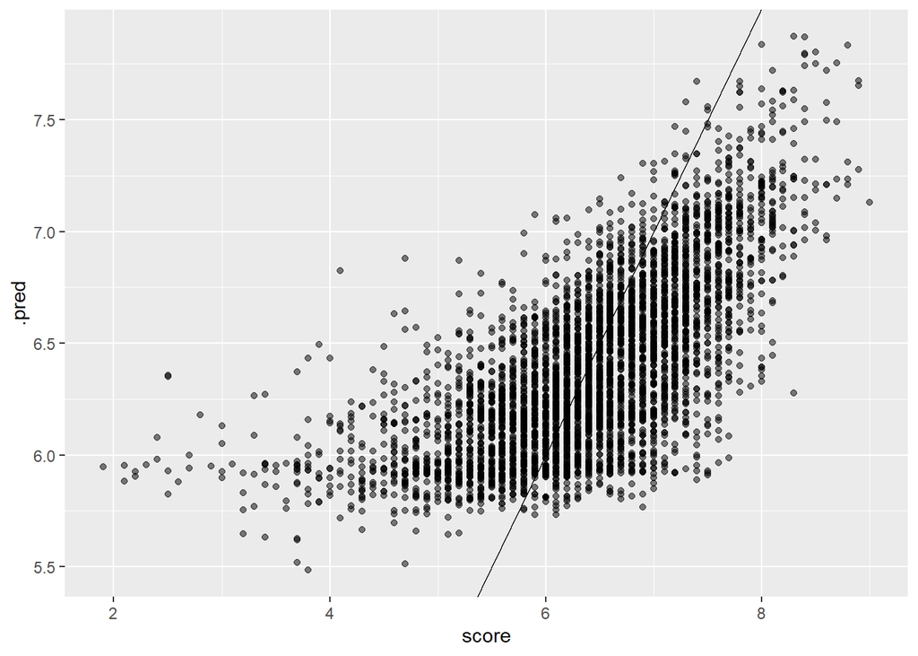

```r
augment(rf_final_fit,
        new_data = movies_train) %>%
  ggplot(aes(score, .pred)) +
  geom_abline() +
  geom_point(alpha = 0.5)
```

From the plot we observe what our rmse value told use above, our model is not predicting very well. We would hope to see the predicted values following the straight line, however, there appears to be a large distribution around the actual values. From the plot, it appears that out model results have high variance and low bias. Thus, our model has predictions that are inaccurate and inconsistent on average.

### Boosted Tree Model

```r
# create spec
boost_model <- boost_tree() %>%
  set_engine("xgboost") %>%
  set_mode("regression")
# create workflow
boost_wkflow <- workflow() %>%
  add_model(boost_model %>%
              set_args(trees = tune(),
                       mtry = tune(),
                       min_n = tune()) %>%
  add_recipe(movies_recipe)
# grid for different values
boost_param_grid <- grid_regular(
  mtry(range=c(1,7)),
  trees(range=c(1,500)),
  min_n(range = c(1,100),levels=10)
# results for different models
boost_param_res <- tune_grid(rf_wkflow,
                          resamples = movies_fold,
                          grid = rf_param_grid)
save(boost_param_res, boost_wkflow, file = "boosted_runs.rda")
```

Let’s visualize the results of different parameter values.

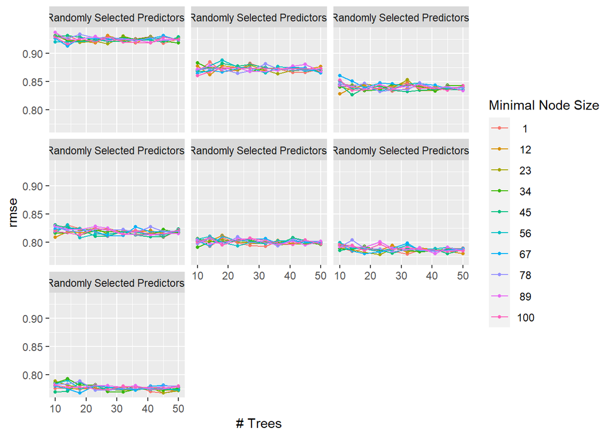

```r
load(file = "C:\\Users\\kathe\\OneDrive\\Desktop\\PSTAT 131\\131-Final-Project\\Data\\boosted_runs.rda")

autoplot(boost_param_res,metric = "rmse")
```

```r
best_boost_res <- select_best(boost_param_res,
                               metric = "rmse")
best_boost_res
```

```
## # A tibble: 1 x 4
##    mtry trees min_n .config
##   <int> <int> <int> <chr>
## 1     7    45     1 Preprocessor1_Model063
```

```r
boost_final <- finalize_workflow(
  boost_wkflow, best_boost_res)
boost_final_fit <- fit(
  boost_final,
  data = movies_train)
```

Let’s see how our model performed on the training data set.

```r
augment(boost_final_fit,
        new_data = movies_train) %>%
  rmse(truth = score, estimate = .pred)
```

```
## # A tibble: 1 x 3
##   .metric .estimator .estimate
##   <chr>   <chr>          <dbl>
## 1 rmse    standard       0.696
```

We got a value of 0.696 for the rmse, which is our smallest value yet! Let’s look a the observed versus expected graph.

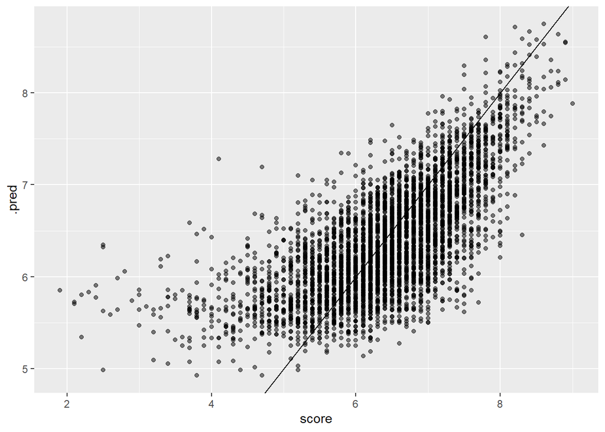

```r
augment(boost_final_fit,
        new_data = movies_train) %>%
  ggplot(aes(score, .pred)) +
  geom_abline() +
  geom_point(alpha = 0.5)
```

### Nearest Neighbor Model

Lastly, we will fit a nearest neighbor model to the data set. In order to do this, we will set up a specification for a nearest neighbor model using the engine “kknn”, create a workflow, a create a parameter grid for the different values of neighbors. The code for this portion was borrowed from the example final project.

```r
knn_model <-
  nearest_neighbor(
    neighbors = tune(),
    mode = "regression") %>%
  set_engine("kknn")

knn_workflow <- workflow() %>%
  add_model(knn_model) %>%
  add_recipe(movies_recipe)

# define grid
knn_grid <- grid_regular(neighbors(range = c(1,10)), levels = 10)

tune_knn <- tune_grid(knn_workflow,
                        resamples = movies_fold,
                        grid = knn_grid)
```

Let’s visualize the result of different neighbors values.

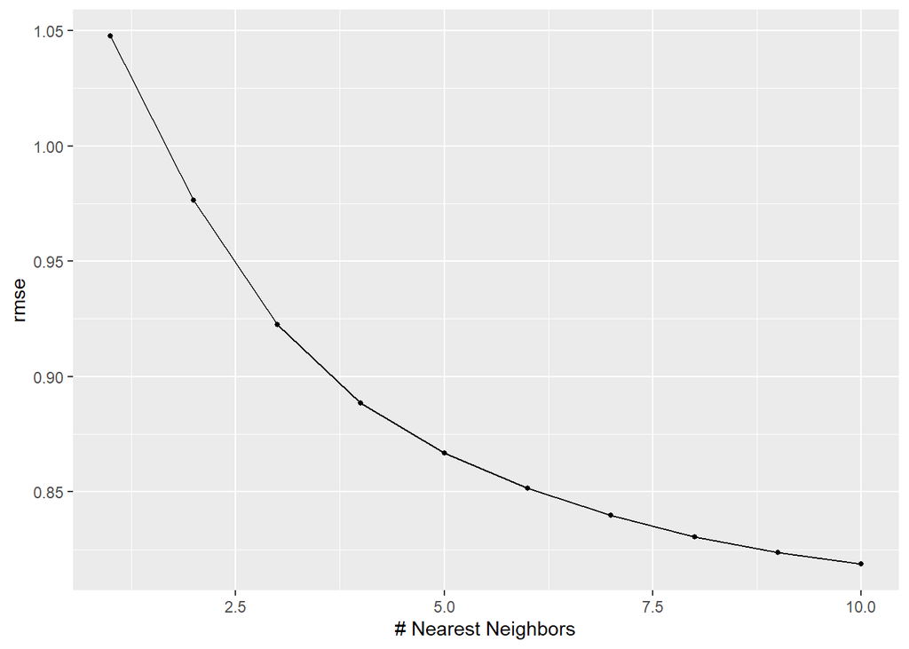

```r
autoplot(tune_knn, metric = "rmse")
```

```r
# select best model
best_knn_res <- select_best(tune_knn,
                              metric = "rmse")
knn_final <- finalize_workflow(
  knn_workflow, best_knn_res)
knn_final_fit <- fit(
  knn_final,
  data = movies_train)
# check performance
augment(knn_final_fit,
        new_data = movies_train) %>%
  rmse(truth = score, estimate = .pred)
```

```
## # A tibble: 1 x 3
##   .metric .estimator .estimate
##   <chr>   <chr>          <dbl>
## 1 rmse    standard       0.550
```

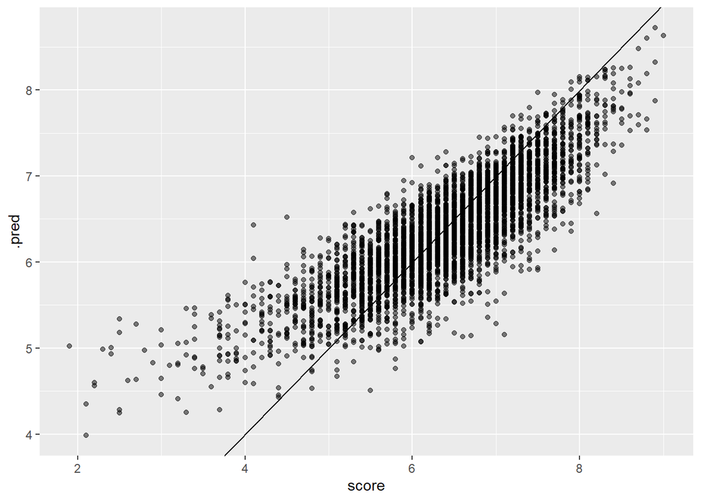

```r
# plot the true versus the predicted values
augment(knn_final_fit,
        new_data = movies_train) %>%
  ggplot(aes(score, .pred)) +
  geom_abline() +
  geom_point(alpha = 0.5)
```

From our rmse value and plot above, we observe that our nearest neighbros model performs the best out of all the models.

### Final Model

W will use our nearest neighbors model since it obtained the lowest rmse value.

### Analysis of the Test Set

```r
augment(knn_final_fit,
        new_data = movies_test) %>%
  rmse(truth = score, estimate = .pred)
```

```
## # A tibble: 1 x 3
##   .metric .estimator .estimate
##   <chr>   <chr>          <dbl>
## 1 rmse    standard       0.796
```

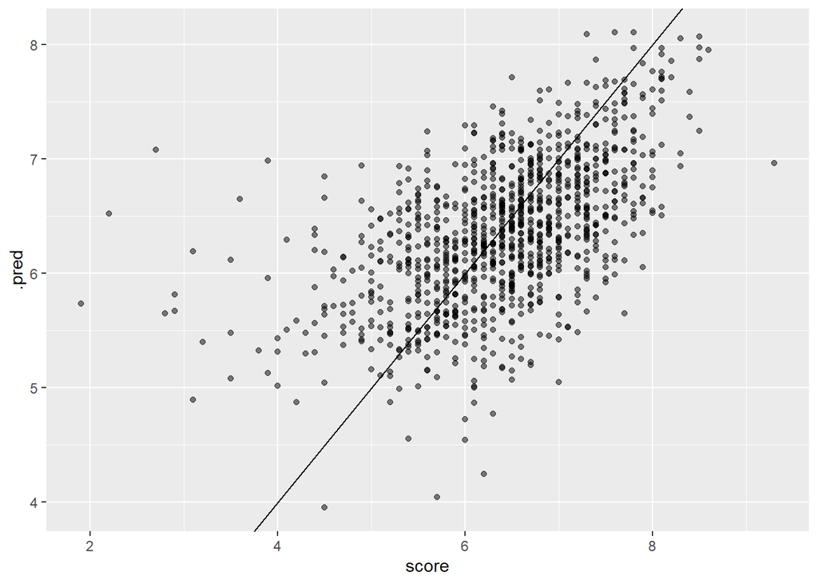

```r
augment(knn_final_fit,
        new_data = movies_test) %>%
  ggplot(aes(score, .pred)) +
  geom_abline() +
  geom_point(alpha = 0.5)
```

## CONCLUSION

I decided to choose these 4 models due to the high number of categorical variables in my data set.

Overall, from the result of our final model tested against the test data, we saw that our model did not predict very well. This could be due to leaving out certain variables that we did not consider important during the EDA and could also be due to the thresholds we created in our recipe. We must also keep in mind that a movie rating is highly subjective, and everyone’s rating criterion might be different in how it related to the predictors in our models. In order for our model to correctly predict a rating, it might have to be on an individual rather than group level. For example, it would be interesting to use my personal Netflix data and the ratings I had given on movies to predict future ratings.

Regardless of the outcome of the model, the movies data set was an interesting way to see what were the most influential parameters when predicting the score of a movie.